# SHAP Tutorial

2023-03-02

This accompanying notebook produces selected results from the tutorial, with the aim of showing how SHAP is used in practice. The results might slightly differ from those in the tutorial, and the plots are organized differently.

You can download the data from Github or from OpenML.

# 1 Load and inspect data

```r
# Data
library(farff)       # 1.1.1 (required by OpenML)
library(OpenML)      # 1.12  (if you download the data from OpenML)

library(withr)       # 2.5.0
library(tidyverse)   # 1.3.2

# Models
library(caret)       # 6.0-93
library(keras)       # 2.11.0
library(lightgbm)    # 3.3.5

# SHAP
library(shapviz)     # 0.6.0
library(kernelshap)  # 0.3.4

# df <- arrow::read_parquet("rdata/df.parquet")
df <- getOMLDataSet(data.id = 45106L)$data

dim(df)
```

```
## [1] 1000000       7
```

```r
head(df)
```

|  | year | town | driver_age | car_weight | car_power | car_age | claim_nb |
| --- | --- | --- | --- | --- | --- | --- | --- |
| 0 | 2018 | 1 | 51 | 1760 | 173 | 3 | 0 |
| 1 | 2019 | 1 | 41 | 1760 | 248 | 2 | 0 |
| 2 | 2018 | 1 | 25 | 1240 | 111 | 2 | 0 |
| 3 | 2019 | 0 | 40 | 1010 | 83 | 9 | 0 |
| 4 | 2018 | 0 | 43 | 2180 | 169 | 5 | 0 |
| 5 | 2018 | 1 | 45 | 1170 | 149 | 1 | 1 |

```r
summary(df)
```

```
##       year           town          driver_age   car_weight     car_power
##  Min.   :2018   Min.   :0.0000   Min.   :18   Min.   : 950   Min.   : 50
##  1st Qu.:2018   1st Qu.:0.0000   1st Qu.:35   1st Qu.:1090   1st Qu.: 86
##  Median :2019   Median :1.0000   Median :45   Median :1240   Median :116
##  Mean   :2019   Mean   :0.6001   Mean   :46   Mean   :1308   Mean   :125
##  3rd Qu.:2019   3rd Qu.:1.0000   3rd Qu.:56   3rd Qu.:1460   3rd Qu.:156
##  Max.   :2019   Max.   :1.0000   Max.   :88   Max.   :3120   Max.   :341
##     car_age          claim_nb
##  Min.   : 0.000   Min.   :0.00000
##  1st Qu.: 1.000   1st Qu.:0.00000
##  Median : 3.000   Median :0.00000
##  Mean   : 4.156   Mean   :0.08933
##  3rd Qu.: 6.000   3rd Qu.:0.00000
##  Max.   :23.000   Max.   :4.00000
```

# 2 Modeling

In this section, we split the data into 90% training and 10% test observations, and fit the three statistical models. Furthermore, we define the function that returns the true model values.

## 2.1 Data split

```r
with_seed(
  8300,
  ix <- sample(nrow(df), 0.9 * nrow(df))
)

y <- "claim_nb"
x <- c("year", "town", "driver_age", "car_weight", "car_power", "car_age")

train <- df[ix, ]
y_train <- train[[y]]
X_train <- data.matrix(train[x])
```

## 2.2 Generalized linear model (GLM)

We start by fitting a (naive) additive linear Poisson regression model.

```r
(fit_glm <- glm(reformulate(x, y), data = train, family = poisson()))
```

```
##
## Call:  glm(formula = reformulate(x, y), family = poisson(), data = train)
##
## Coefficients:
## (Intercept)         year         town   driver_age   car_weight    car_power
##  -1.812e+01    7.569e-03    3.577e-01   -4.386e-03   -3.527e-05    4.066e-03
##     car_age
##  -2.164e-02
##
## Degrees of Freedom: 899999 Total (i.e. Null);  899993 Residual
## Null Deviance:       399400
## Residual Deviance: 393100    AIC: 548500
```

## 2.3 Deep neural net

We use TensorFlow to fit the deep neural net.

```r
# Standardization
scaler <- preProcess(X_train, method = "range", rangeBounds = c(-1, 1))

# Callbacks
cb <- list(
  callback_early_stopping(patience = 20),
  callback_reduce_lr_on_plateau(patience = 5)
)

# Architecture
make_nn <- function() {
  k_clear_session()
  tensorflow::set_random_seed(4349)

  input <- layer_input(length(x))

  output <- input %>%
    layer_dense(units = 40, activation = "tanh") %>%
    layer_dense(units = 20, activation = "tanh") %>%
    layer_dense(units = 10, activation = "tanh") %>%
    layer_dense(units = 1, activation = "exponential")

  keras_model(input, output)
}

# Create, compile and fit model
fit_nn <- make_nn() %>%
  compile(optimizer = optimizer_adam(learning_rate = 1e-4), loss = loss_poisson)

summary(fit_nn)
```

```
## Model: "model"
## ________________________________________________________________________________
##  Layer (type)                       Output Shape                    Param #
## ================================================================================
##  input_1 (InputLayer)               [(None, 6)]                     0
##  dense_3 (Dense)                    (None, 40)                      280
##  dense_2 (Dense)                    (None, 20)                      820
##  dense_1 (Dense)                    (None, 10)                      210
##  dense (Dense)                      (None, 1)                       11
## ================================================================================
## Total params: 1,321
## Trainable params: 1,321
## Non-trainable params: 0
## ________________________________________________________________________________
```

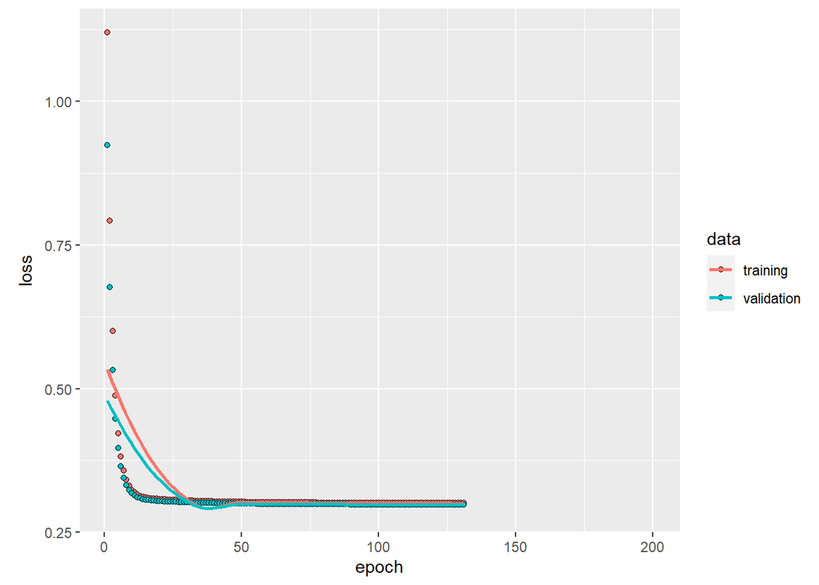

```r
history <- fit_nn %>%
  fit(
    x = predict(scaler, X_train),
    y = y_train,
    epochs = 200,
    batch_size = 1e4,
    validation_split = 0.1,
    callbacks = cb,
    verbose = 0
  )
plot(history, metrics = "loss")
```

## 2.4 LightGBM

To fit a boosted trees model, we use LightGBM. The parameters have been tuned outside this script by combining early-stopping with random parameter search cross-validation.

```r
dtrain <- lgb.Dataset(
  X_train,
  label = y_train,
  params = list(feature_pre_filter = FALSE)
)

params <- list(
  learning_rate = 0.05,
  objective = "poisson",
  metric = "poisson",
  num_leaves = 7,
  min_data_in_leaf = 50,
  min_sum_hessian_in_leaf = 0.001,
  colsample_bynode = 0.8,
  bagging_fraction = 0.8,
  lambda_l1 = 3,
  lambda_l2 = 5,
  num_threads = 7
)

fit_lgb <- lgb.train(params = params, data = dtrain, nrounds = 300)
```

```
## [LightGBM] [Warning] Auto-choosing row-wise multi-threading, the overhead of testing was 0.010411 seconds.
## You can set `force_row_wise=true` to remove the overhead.
## And if memory is not enough, you can set `force_col_wise=true`.
## [LightGBM] [Info] Total Bins 542
## [LightGBM] [Info] Number of data points in the train set: 900000, number of used features: 6
## [LightGBM] [Info] Start training from score -2.415182
```

## 2.5 True model

Since we use simulated data, the true underlying frequency model is known:

```r
age_effect <- function(age) {
  x <- (age - 66) / 60
  0.05 + x^8 + 0.4*x^3 + 0.3*x^2 + 0.06*x
}

true_model <- function(df) {
  log_lambda <- with(
    df,
    0 +
      0.15 * town +
      + log(age_effect(driver_age)) +
      (0.3 + 0.15 * town) * car_power / 100 +  # interaction 1
    #  0.1 * car_power / (car_weight / 100)^2 + # interaction 2
      -0.02 * car_age
  )
  exp(log_lambda)
}

# Check
true_model(head(df))
```

```
## [1] 0.11324469 0.16716395 0.12691164 0.05253090 0.07364009 0.10871680
```

# 3 SHAP analysis

Let’s analyze our models with SHAP.

## 3.1 Preparations

The first steps in the SHAP analysis is to select a dataset of 1000 rows to be explained. Furthermore, for model-agnostic Kernel SHAP, we additionally sample a smaller dataset, serving as background data for integrating out marginal means.

```r
with_seed(
  3948, {
    X_explain <- train[sample(nrow(train), 1000), x]
    bg <- train[sample(nrow(train), 200), ]
  }
)
```

## 3.2 LightGBM and TreeSHAP

Let’s explain our LightGBM model with the extremely efficient TreeSHAP algorithm.

```r
system.time(
  shap_lgb <- shapviz(fit_lgb, X_pred = data.matrix(X_explain))
)
```

```
##        User      System verstrichen
##        0.36        0.00        0.07
```

### 3.2.1 Waterfall plot of first observation

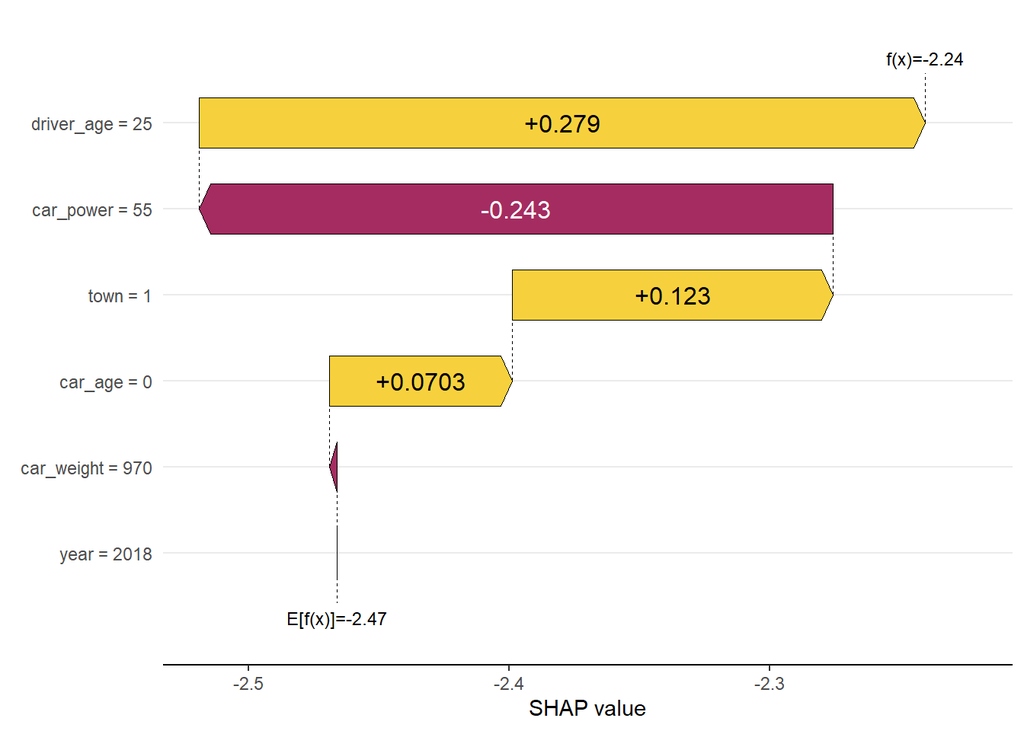

```r
sv_waterfall(shap_lgb, row_id = 1)
```

### 3.2.2 SHAP importance: Barplot and summary plot

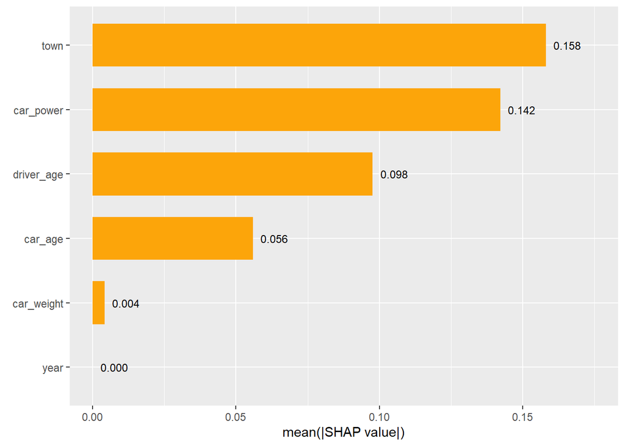

```r
sv_importance(shap_lgb, show_numbers = TRUE)
```

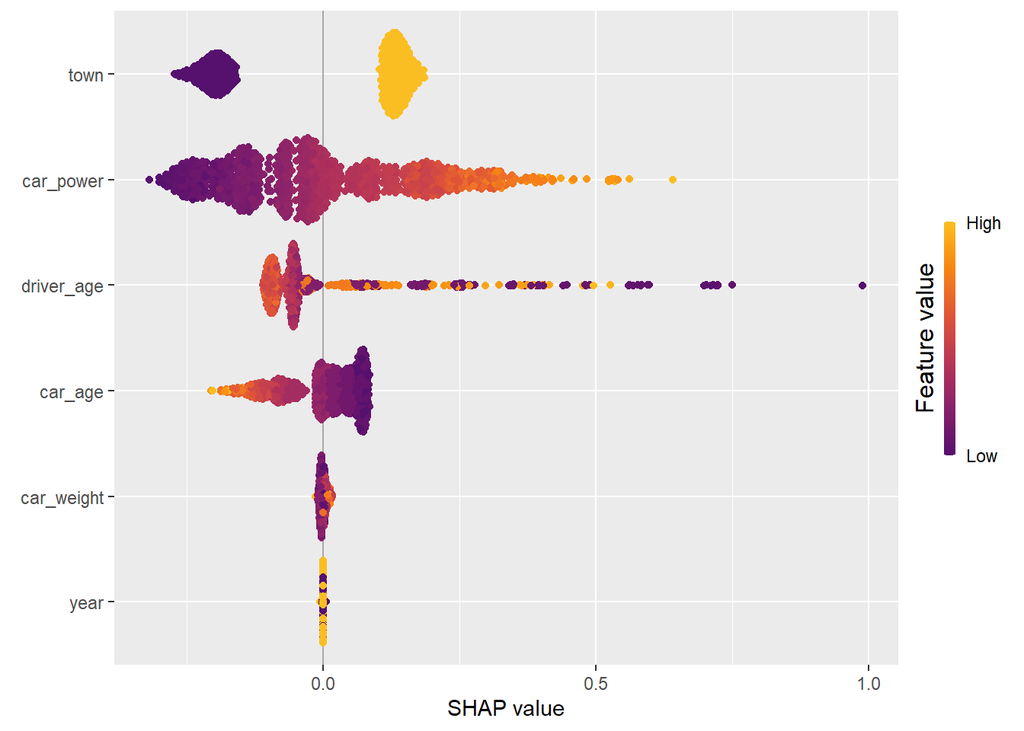

```r
sv_importance(shap_lgb, kind = "bee")
```

### 3.2.3 SHAP dependence plots

Each figure uses the potentially strongest interacting feature on the color scale. Therefore, the colors differ from picture to picture (and later also from model to model).

```r
for (xvar in x) {
  (sv_dependence(shap_lgb, xvar, alpha = 0.5) +
    ggtitle(xvar) +
    ylim(-0.5, 1.05)) %>%
  print()
}
```

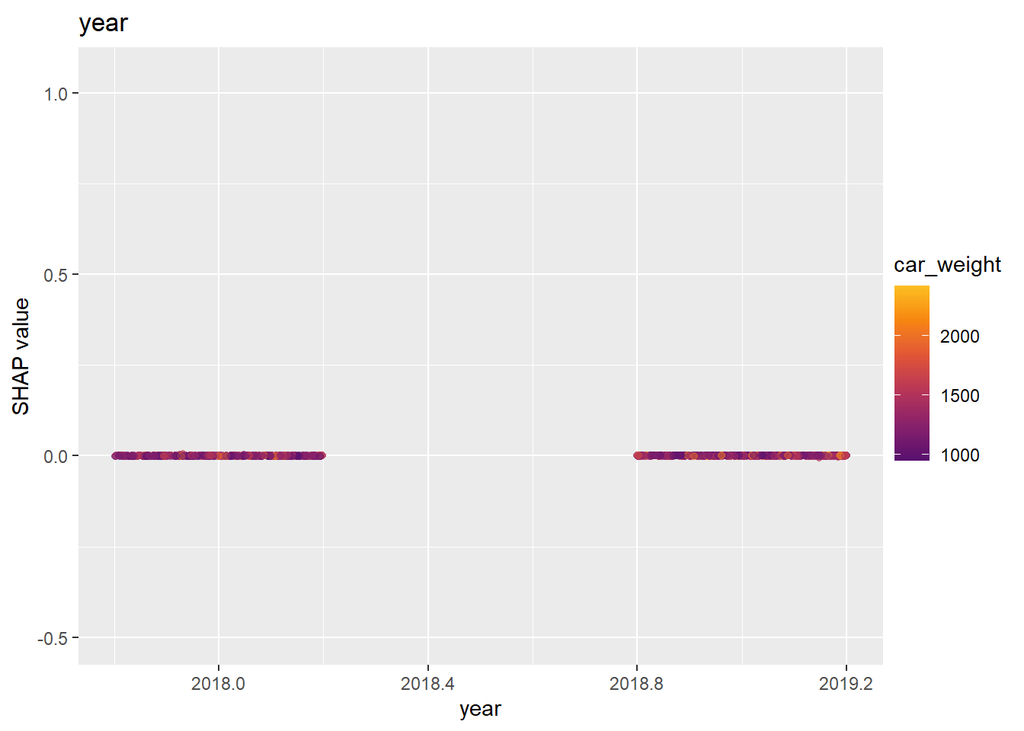

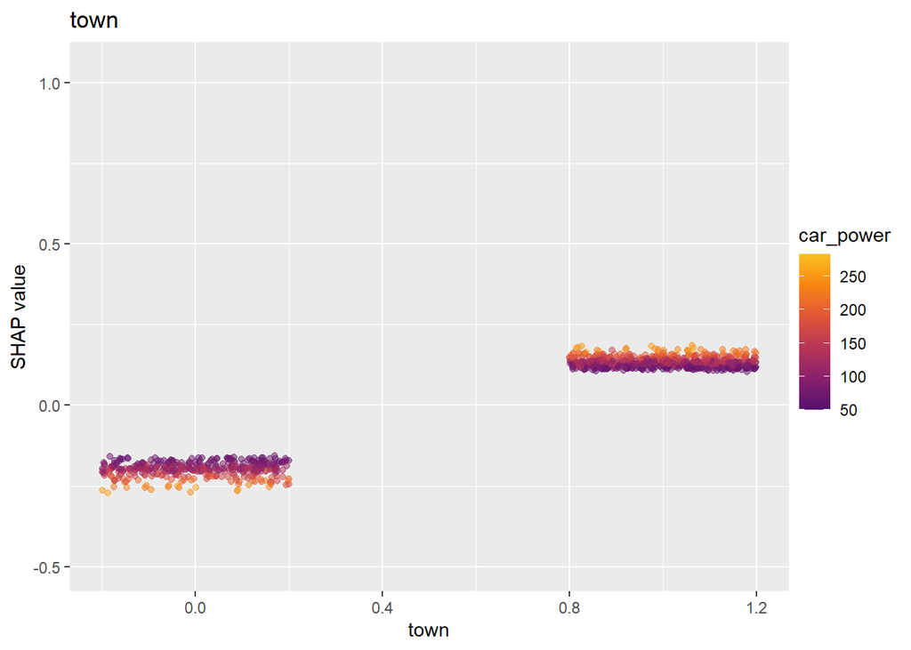

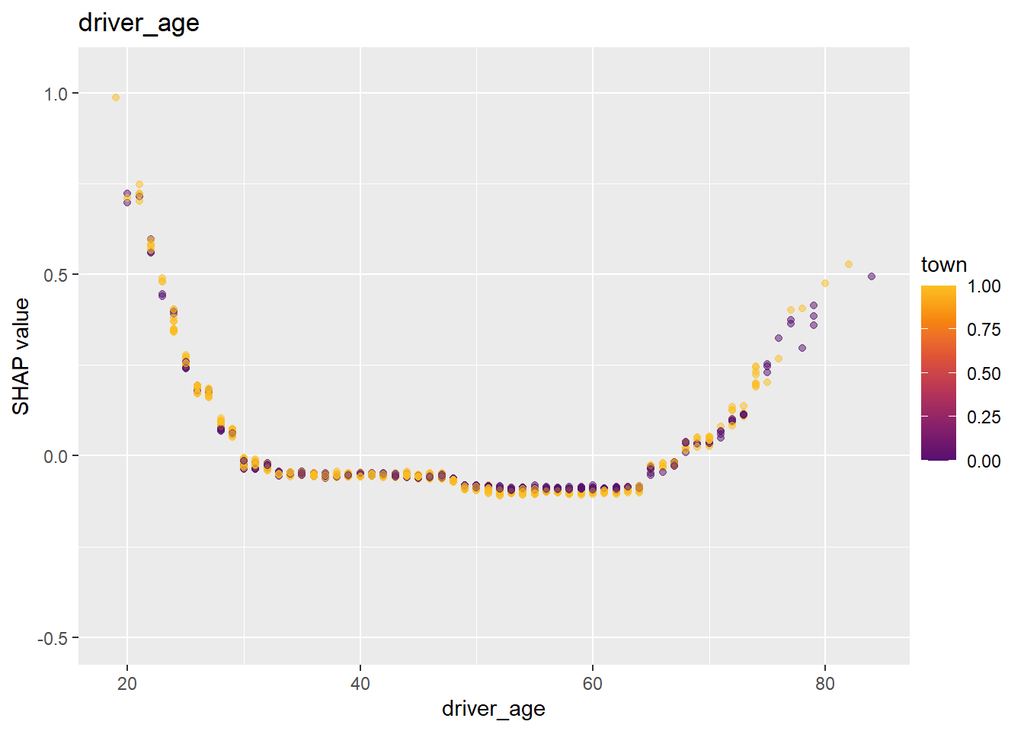

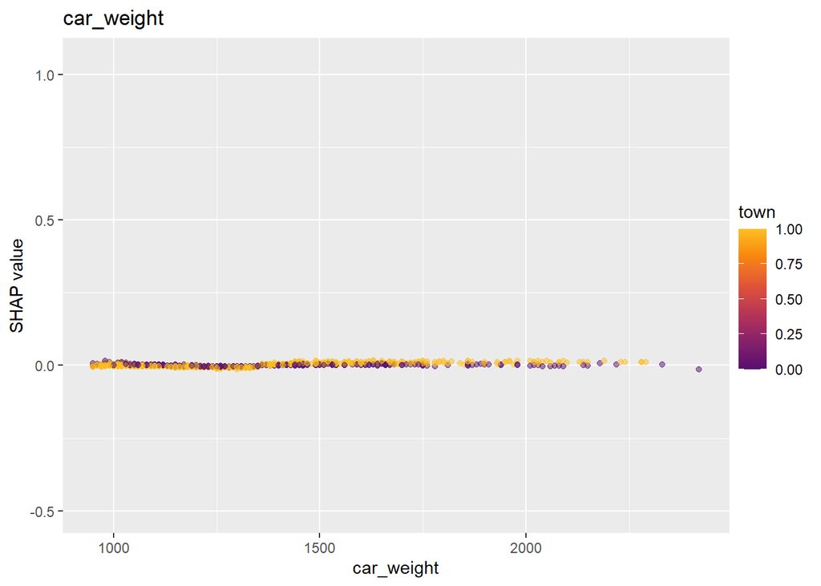

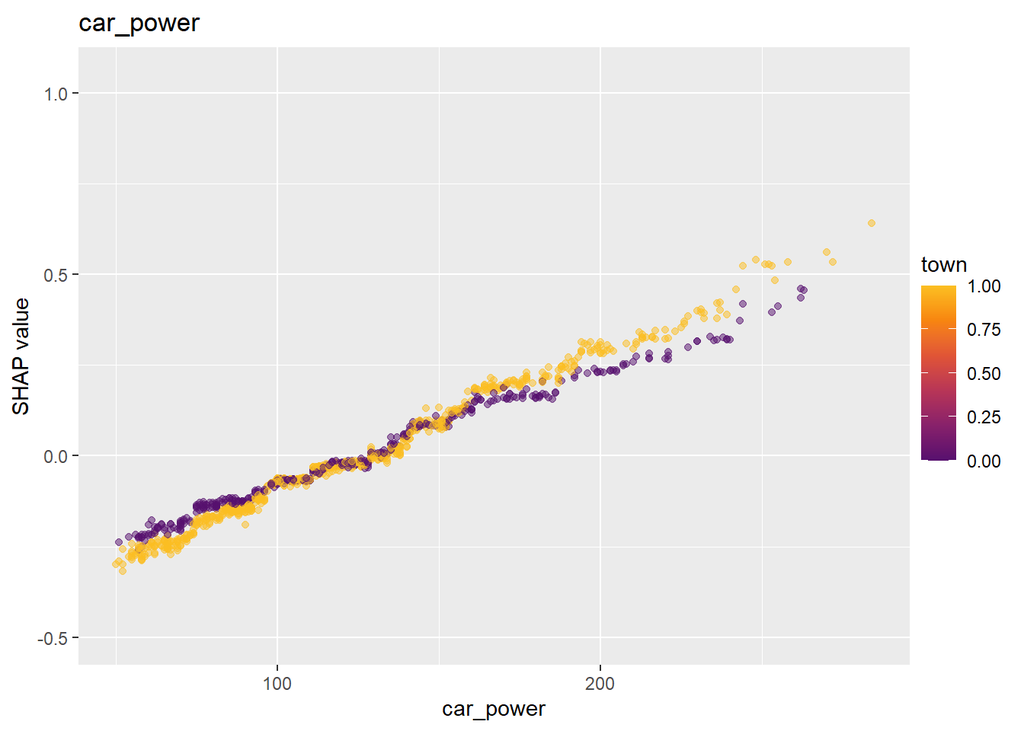

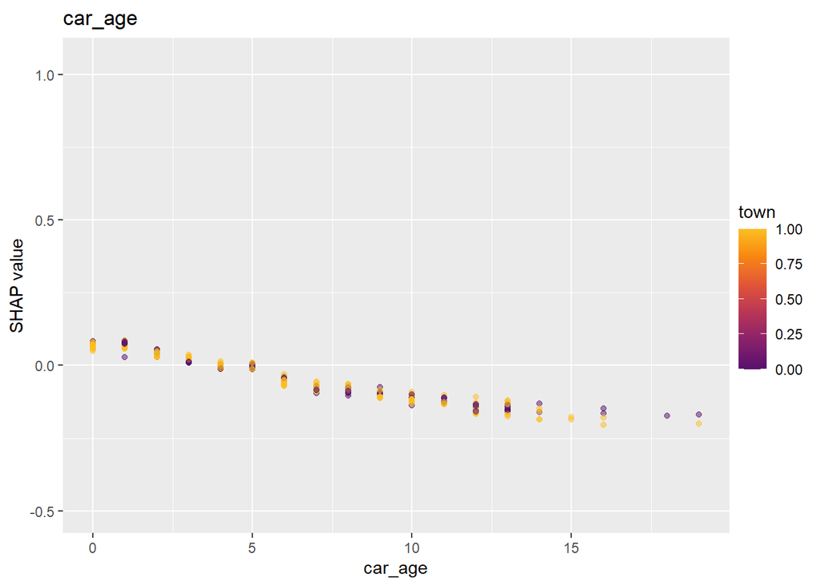

## 3.3 GLM with Kernel SHAP

For all other models, including our GLM, we use model-agnostic Kernel SHAP, and focus on SHAP dependence plots. (Setting `verbose = FALSE` suppresses the progress bar - it does not play well with R Markdown).

```r
system.time(
  shap_glm <- shapviz(kernelshap(fit_glm, X = X_explain, bg_X = bg, verbose = FALSE))
)
```

```
##        User      System verstrichen
##       16.19        2.19       26.71
```

```r
for (xvar in x) {
  (sv_dependence(shap_glm, xvar, alpha = 0.5) +
    ggtitle(xvar) +
    ylim(-0.5, 1.05)) %>%
  print()
}
```

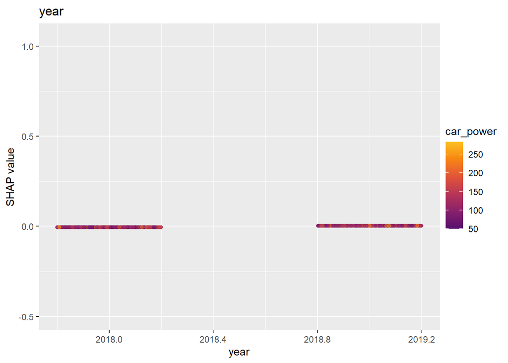

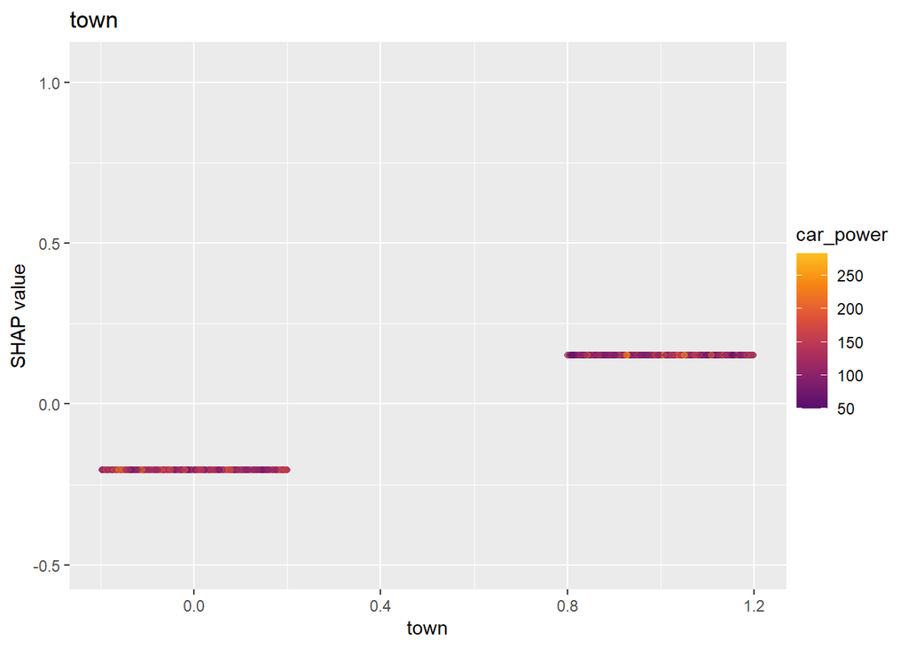

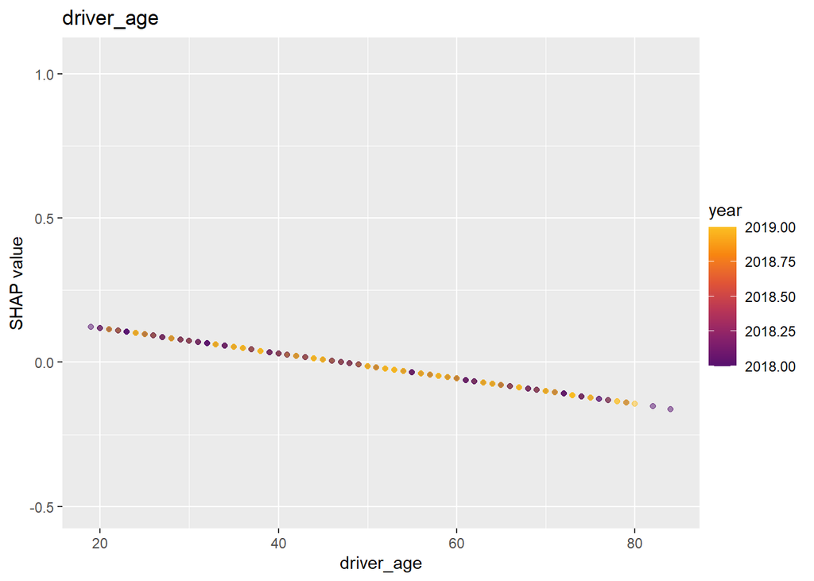

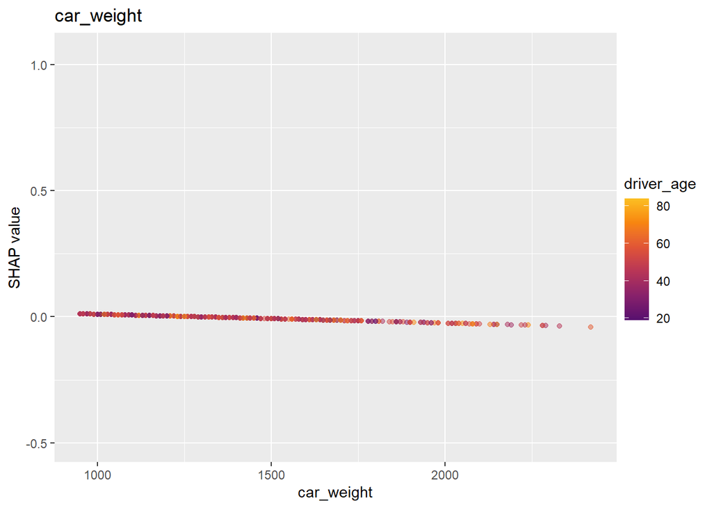

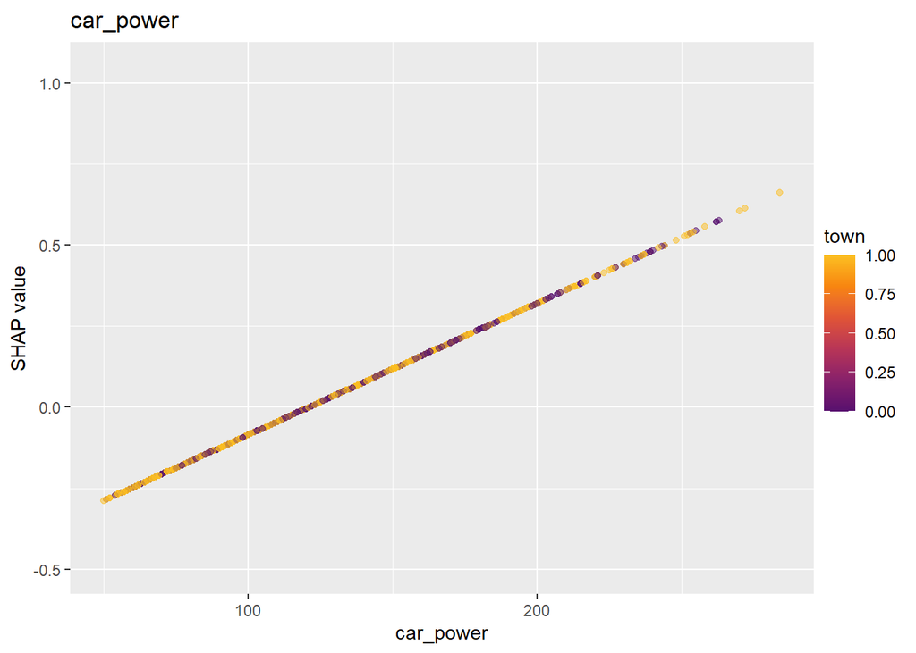

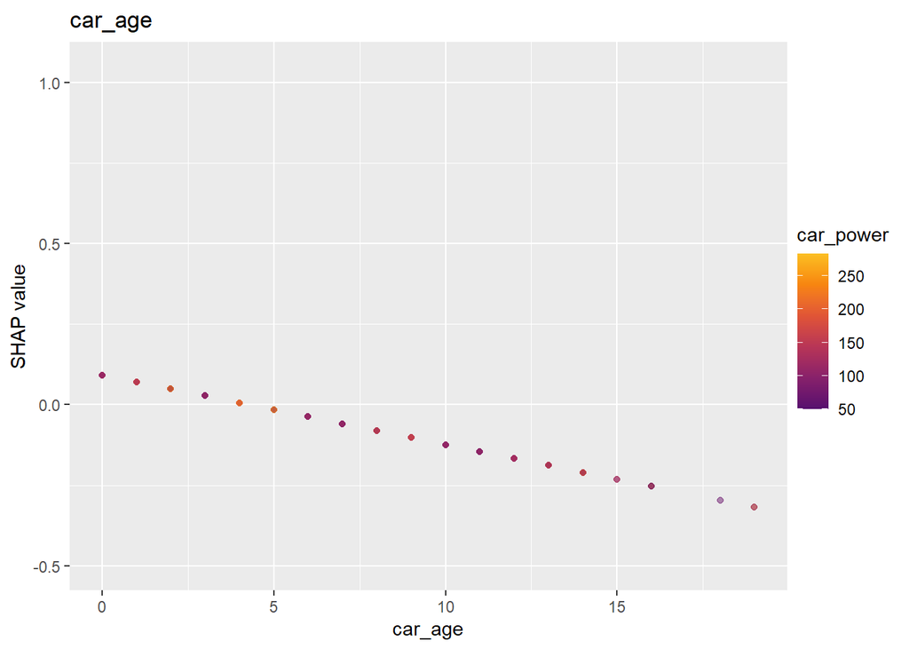

## 3.4 Neural net with Kernel SHAP

```r
# Function that maps data.frame to neural net input and calculates (log) predictions
pred_nn_ln <- function(model, df) {
  X <- data.matrix(df[x])
  X_scaled <- predict(scaler, X)
  log(predict(model, X_scaled, batch_size = 1e4, verbose = 0))
}

# Kernel SHAP
system.time(
  shap_nn <- shapviz(
    kernelshap(fit_nn, X = X_explain, bg_X = bg, pred_fun = pred_nn_ln, verbose = FALSE)
  )
)
```

```
##        User      System verstrichen
##       76.70        3.16      119.21
```

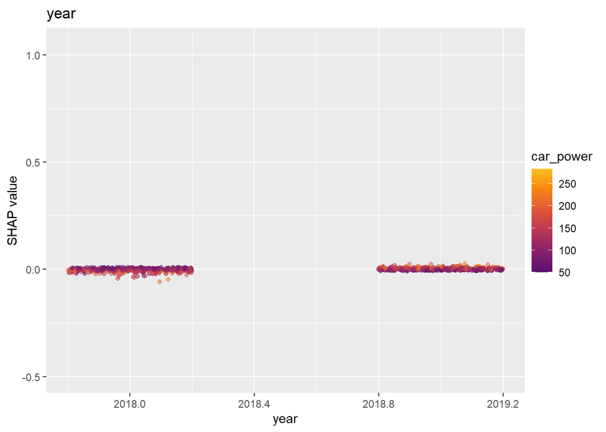

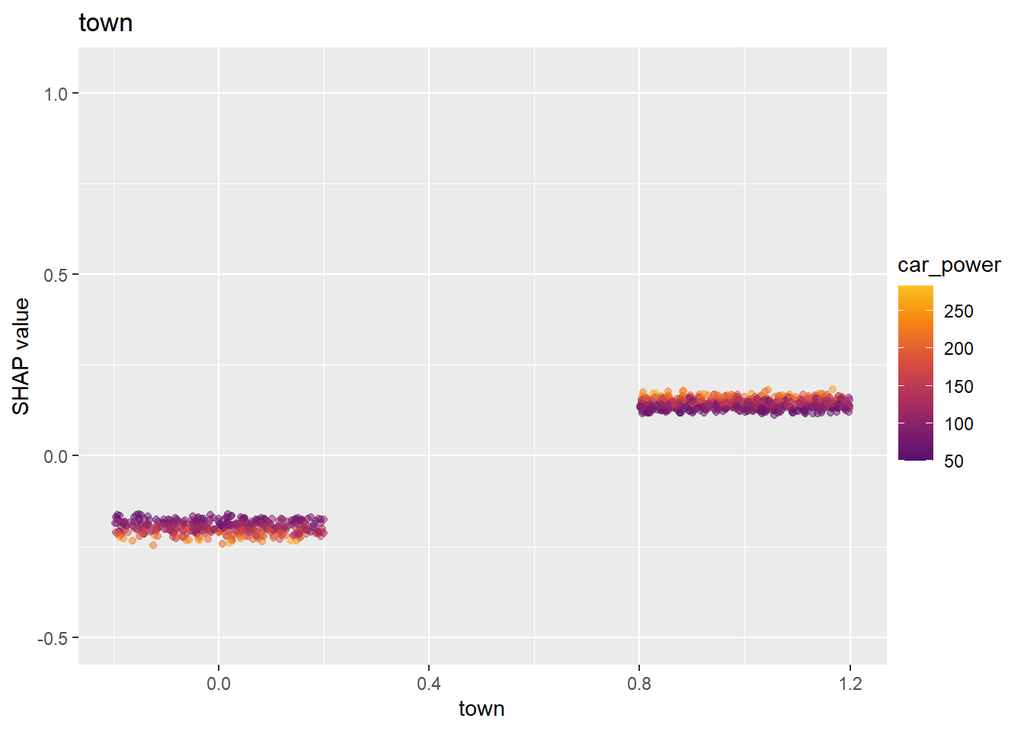

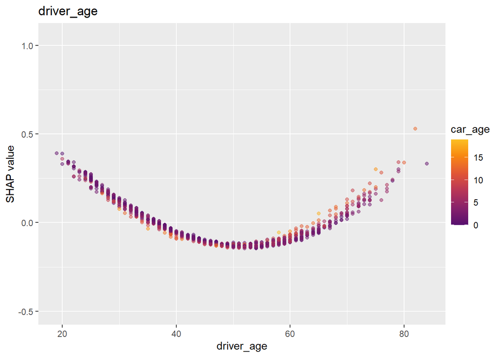

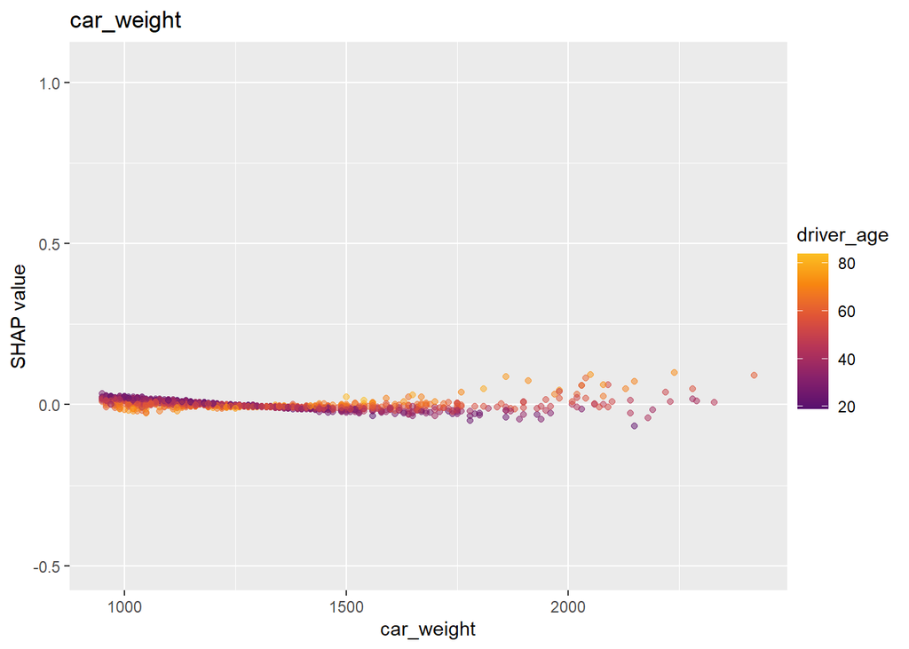

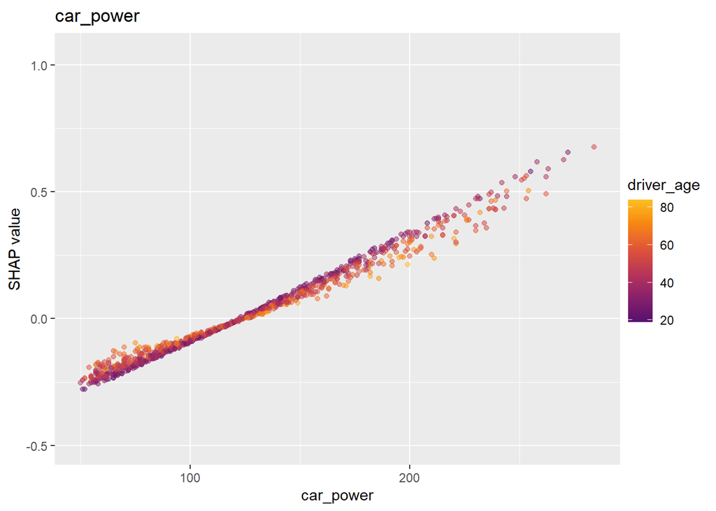

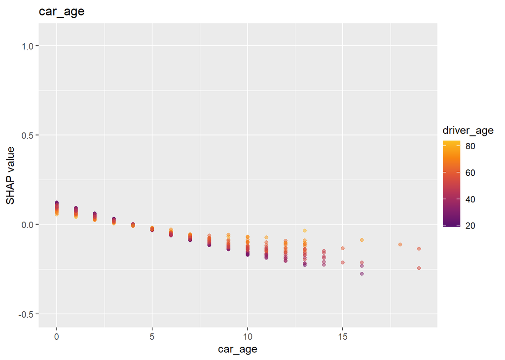

```r
# Dependence plots
for (xvar in x) {
  (sv_dependence(shap_nn, xvar, alpha = 0.5) +
    ggtitle(xvar) +
    ylim(-0.5, 1.05)) %>%
  print()
}
```

## 3.5 True model with Kernel SHAP

```r
system.time(
  shap_truth <- shapviz(
    kernelshap(
      "truth",
      X = X_explain,
      bg_X = bg,
      pred_fun = function(m, X) log(true_model(X)),
      verbose = FALSE
    )
  )
)
```

```
##        User      System verstrichen
##       17.98        0.47       27.35
```

```r
for (xvar in x) {
  (sv_dependence(shap_truth, xvar, alpha = 0.5) +
    ggtitle(xvar) +
    ylim(-0.5, 1.05)) %>%
  print()
}
```

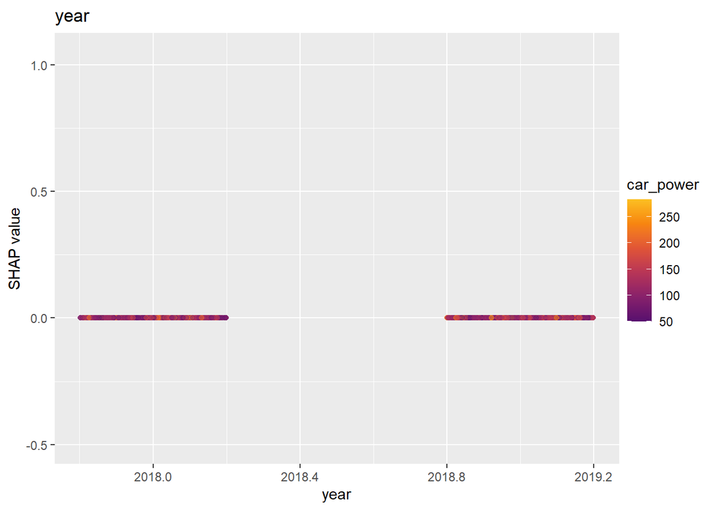

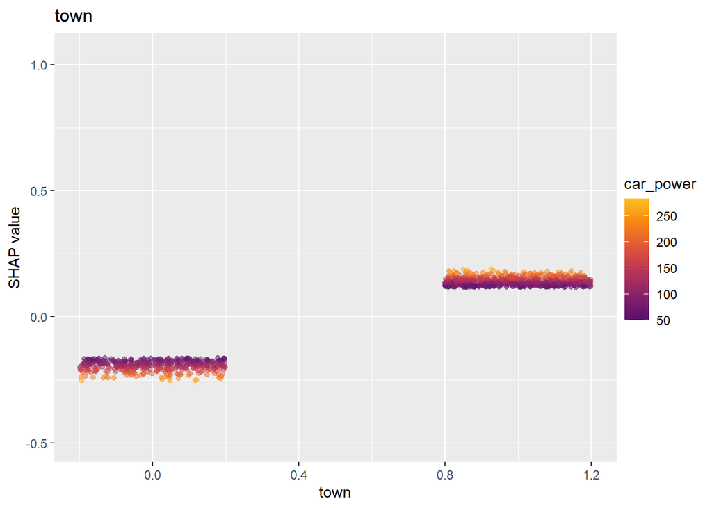

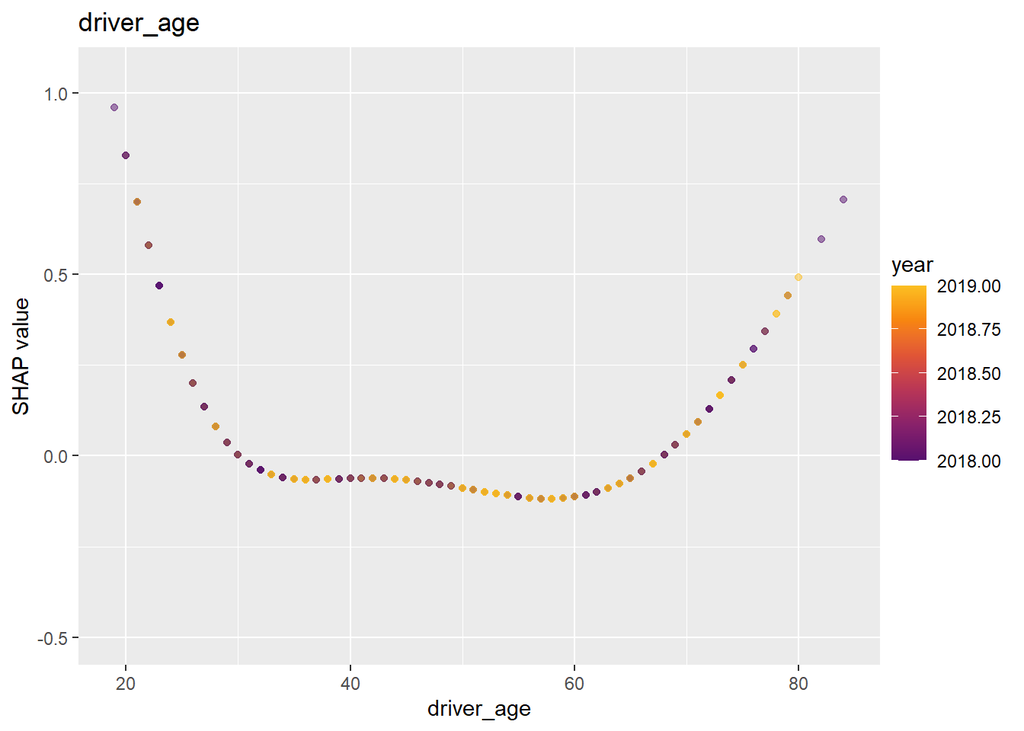

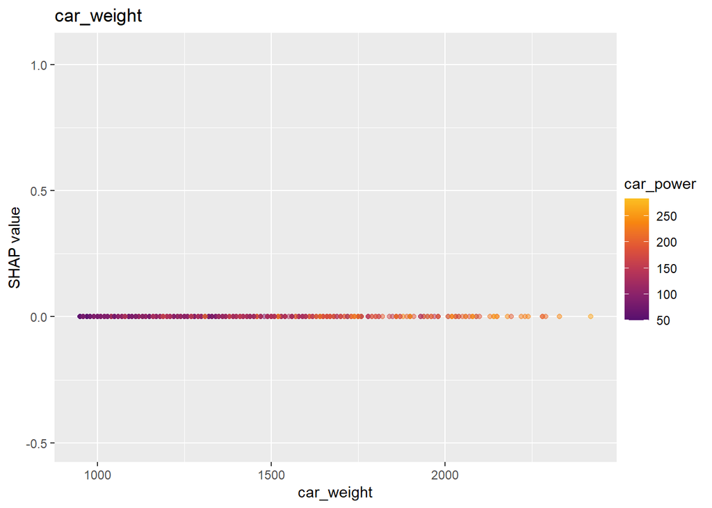

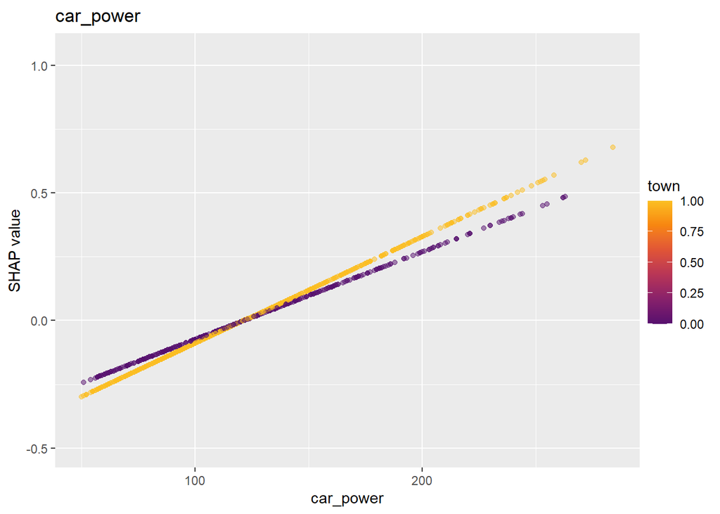

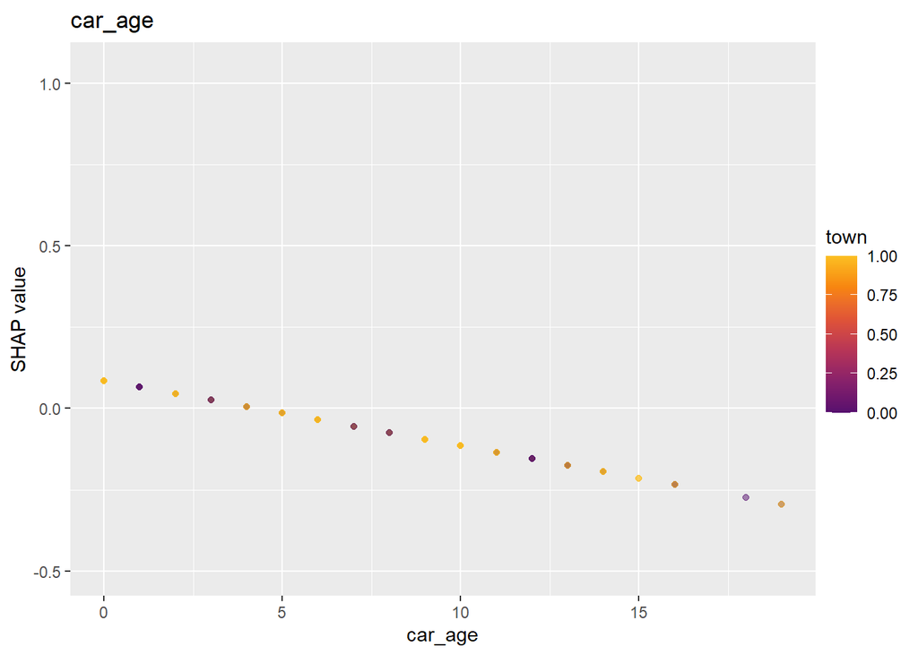